# Coursera: Machine Learning Project

Tsatkhlanov Kirill

2024-07-28

## Loading Vital Packages and Data

```r
library(dplyr)
library(data.table)
library(caret)

set.seed(123)

data <- rio::import("./pml_training.csv") %>% as_tibble()
validation <- rio::import("./pml_testing.csv") %>% as_tibble()
```

## Adjusting Data

Prior building any Machine Learning model, it is vital to pick necessary risk drivers and impute missing values. In our case we have several columns that nearly 90% consist of missing values. In this case the “knnImpuation” function will not work and other imputation mechanisms would damage the representativeness of the data, as the missing quota is too high. In the code below I remove all deficiencies and complete the same procedure for the validation data set.

```r
data_cleaned <- data %>%
  select_if(~ !any(is.na(.))) %>%
  select(-ends_with("x"), -ends_with("y"), -ends_with("z"),
         -c("V1", "user_name", "raw_timestamp_part_1", "raw_timestamp_part_2", "cvtd_timestamp"),
         -c("new_window", "num_window"))

data_cleaned$classe <- as.factor(data_cleaned$classe)

validation_cleaned <- validation %>%
  select_if(~ !any(is.na(.))) %>%
  select(-ends_with("x"), -ends_with("y"), -ends_with("z"),
         -c("V1", "user_name", "raw_timestamp_part_1", "raw_timestamp_part_2", "cvtd_timestamp"),
         -c("new_window", "num_window"))
```

## Slicing Data for Cross Validation

For the cross validation purposes I sliced the data into training and testing data set. The training data set contains 75% of the original data and the testing only 25%.

```r
inTrain <- createDataPartition(y = data_cleaned$classe, p = 0.75, list = FALSE)

training <- data_cleaned[inTrain, ]
testing <- data_cleaned[-inTrain, ]
```

## Plotting Predictors

Most of the predictors follow the same distribution pattern as shown in the graph below. Thus, no preprozessing is needed

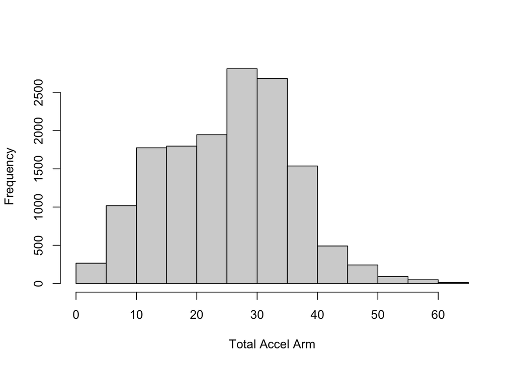

```r
hist(training$total_accel_arm, main = "", xlab = "Total Accel Arm")
```

## Fitting Model

The goal is to build a high accurate model and for this reason I have chosen the method of “Random Forests”.

```r
modelFit <- train(classe ~ ., data = training, method = "rf")
```

## Predicting Results

In the final step I check the performance of the model on the testing data set. As shown below the accuracy if very high, what let us conclude that the model has captured most relevant features for the training data set.

```r
predictions_rf <- predict(modelFit, testing)
confusionMatrix(predictions_rf, testing$classe)
```

```
## Confusion Matrix and Statistics
##
##           Reference
## Prediction    A    B    C    D    E
##          A 1394    4    0    0    0
##          B    1  932    6    1    1
##          C    0   12  842    1    4
##          D    0    1    7  802    2
##          E    0    0    0    0  894
##
## Overall Statistics
##
##                Accuracy : 0.9918
##                  95% CI : (0.9889, 0.9942)
##     No Information Rate : 0.2845
##     P-Value [Acc > NIR] : < 2.2e-16
##
##                   Kappa : 0.9897
##
##  Mcnemar's Test P-Value : NA
##
## Statistics by Class:
##
##                      Class: A Class: B Class: C Class: D Class: E
## Sensitivity            0.9993   0.9821   0.9848   0.9975   0.9922
## Specificity            0.9989   0.9977   0.9958   0.9976   1.0000
## Pos Pred Value         0.9971   0.9904   0.9802   0.9877   1.0000
## Neg Pred Value         0.9997   0.9957   0.9968   0.9995   0.9983
## Prevalence             0.2845   0.1935   0.1743   0.1639   0.1837
## Detection Rate         0.2843   0.1900   0.1717   0.1635   0.1823
## Detection Prevalence   0.2851   0.1919   0.1752   0.1656   0.1823
## Balanced Accuracy      0.9991   0.9899   0.9903   0.9975   0.9961
```